# 数字经济发展与国家科技创新能力的关系分析

基于世界银行全球发展指标（2010-2024）

2026-06-12

# 1 引言

## 1.1 研究背景

在数字经济时代，互联网基础设施建设和科技创新能力已成为衡量国家竞争力的核心指标。 世界银行每年收集全球200多个国家的发展指标数据，涵盖经济、科技、教育、基础设施等多个维度。 这些数据为研究数字经济发展与国家科技创新能力之间的关系提供了宝贵的实证基础。

**核心探究问题：** 1. 不同经济发展水平的国家在数字基础设施方面存在怎样的差异？ 2. 互联网普及率与研发投入之间是否存在显著相关关系？ 3. 能否通过数字基础设施指标预测一国的科技创新产出？

## 1.2 数据来源

本报告使用的数据来源于 **Kaggle 平台**上的 **World Bank Indicators (1960-Present)** 数据集：

> **下载链接：** https://www.kaggle.com/datasets/georgejdinicola/world-bank-indicators

该数据集整理自世界银行公开数据平台（World Bank Open Data），包含 800+ 项指标、268个国家/地区、 跨越 1960 年至今的时间序列面板数据。本报告选取 2010-2024 年间的数据，聚焦于科学技 术、数字基础设施和经济指标三个主题。

# 2 数据说明

## 2.1 变量字典

表1：变量字典

[output not shown]

## 2.2 数据概览

```r
df <- read_csv("data/digital_economy_innovation.csv")

cat("数据维度：", nrow(df), "行 ×", ncol(df), "列\n")
```

```
## 数据维度： 3440 行 × 17 列
```

```r
cat("国家/地区数：", n_distinct(df$country), "\n")
```

```
## 国家/地区数： 251
```

```r
cat("时间范围：", min(df$year), "-", max(df$year), "\n")
```

```
## 时间范围： 2010 - 2024
```

```r
head(df, 8) %>% kable(caption = "表2：数据预览（前8行）")
```

表2：数据预览（前8行）

[output not shown]

# 3 数据预处理

## 3.1 缺失值检测与处理

```r
# 计算各变量缺失比例
missing_summary <- df %>%
  summarise(across(everything(), ~ sum(is.na(.)))) %>%
  pivot_longer(everything(), names_to = "变量", values_to = "缺失数") %>%
  mutate(缺失比例 = round(缺失数 / nrow(df) * 100, 1)) %>%
  arrange(desc(缺失比例))

kable(missing_summary, caption = "表3：各变量缺失值统计")
```

表3：各变量缺失值统计

[output not shown]

**缺失值处理策略：** - 对于缺失比例较低（<30%）的变量，保留含缺失值的行，在具体分析时使用 `na.rm = TRUE` - 对于建模所需的关键变量（互联网普及率、研发支出、GDP等），创建完整案例分析子集 - 缺失值不做简单填充以避免引入偏差

```r
# 创建完整案例子集（用于回归建模）
df_model <- df %>%
  filter(
    !is.na(`Individuals using the Internet (% of population)`),
    !is.na(`Research and development expenditure (% of GDP)`),
    !is.na(`GDP per capita (current US$)`),
    !is.na(`High-technology exports (% of manufactured exports)`)
  )

cat("完整案例子集：", nrow(df_model), "行（原数据", nrow(df), "行的",
    round(nrow(df_model)/nrow(df)*100, 1), "%）\n")
```

```
## 完整案例子集： 1104 行（原数据 3440 行的 32.1 %）
```

```r
cat("覆盖国家数：", n_distinct(df_model$country), "\n")
```

```
## 覆盖国家数： 127
```

## 3.2 变量重编码与新变量创建

```r
df <- df %>%
  mutate(
    # 1. 创建收入分组（基于人均GDP四分位数）
    income_group = case_when(
      `GDP per capita (current US$)` < 2000 ~ "低收入",
      `GDP per capita (current US$)` < 8000 ~ "中低收入",
      `GDP per capita (current US$)` < 25000 ~ "中高收入",
      `GDP per capita (current US$)` >= 25000 ~ "高收入",
      TRUE ~ NA_character_
    ),

    # 2. 数字化综合指数（互联网+移动+宽带的平均值）
    digital_index = (`Individuals using the Internet (% of population)` +
                     `Mobile cellular subscriptions (per 100 people)` +
                     `Fixed broadband subscriptions (per 100 people)`) / 3,

    # 3. 对数变换（处理偏态分布）
    log_gdp = log(`GDP per capita (current US$)` + 1),
    log_patents = log(`Patent applications, residents` + 1),
    log_articles = log(`Scientific and technical journal articles` + 1),
    log_internet_servers = log(`Secure Internet servers (per 1 million people)` + 1),

    # 4. 高数字化标记
    high_digital = if_else(
      `Individuals using the Internet (% of population)` > 75,
      "高数字化", "低/中数字化"
    )
  )

# 将收入分组转为有序因子
df$income_group <- factor(df$income_group,
                           levels = c("低收入", "中低收入", "中高收入", "高收入"),
                           ordered = TRUE)

cat("新变量创建完成：income_group, digital_index, log_gdp, log_patents, log_articles, log_internet_servers, high_digital\n")
```

```
## 新变量创建完成：income_group, digital_index, log_gdp, log_patents, log_articles, log_internet_servers, high_digital
```

```r
cat("本次使用的 dplyr/tidyr 函数：filter(), select(), mutate(), group_by(), summarise(), arrange(), pivot_longer(), case_when(), if_else(), across()\n")
```

```
## 本次使用的 dplyr/tidyr 函数：filter(), select(), mutate(), group_by(), summarise(), arrange(), pivot_longer(), case_when(), if_else(), across()
```

# 4 探索性数据分析（EDA）

## 4.1 描述性统计与分组汇总

```r
# 分组汇总表1：按收入分组汇总数字基础设施指标
table1 <- df %>%
  filter(!is.na(income_group), year >= 2020) %>%
  group_by(income_group) %>%
  summarise(
    国家数 = n_distinct(country),
    互联网普及率_均值 = mean(`Individuals using the Internet (% of population)`, na.rm = TRUE),
    互联网普及率_中位数 = median(`Individuals using the Internet (% of population)`, na.rm = TRUE),
    互联网普及率_标准差 = sd(`Individuals using the Internet (% of population)`, na.rm = TRUE),
    移动电话普及率_均值 = mean(`Mobile cellular subscriptions (per 100 people)`, na.rm = TRUE),
    固定宽带普及率_均值 = mean(`Fixed broadband subscriptions (per 100 people)`, na.rm = TRUE),
    安全服务器_均值 = mean(`Secure Internet servers (per 1 million people)`, na.rm = TRUE),
    .groups = "drop"
  )

kable(table1, digits = 1,
      caption = "表4：不同收入组国家数字基础设施描述统计（2020-2024）")
```

表4：不同收入组国家数字基础设施描述统计（2020-2024）

| income_group | 国家数 | 互联网普及率_均值 | 互联网普及率_中位数 | 互联网普及率_标准差 | 移动电话普及率_均值 | 固定宽带普及率_均值 | 安全服务器_均值 |
| --- | --- | --- | --- | --- | --- | --- | --- |
| 低收入 | 63 | 30.3 | 27.6 | 15.9 | 82.1 | 1.1 | 145.4 |
| 中低收入 | 95 | 67.0 | 70.6 | 15.7 | 107.4 | 9.6 | 5515.8 |
| 中高收入 | 71 | 82.3 | 83.2 | 7.7 | 123.8 | 24.4 | 13246.2 |
| 高收入 | 56 | 93.5 | 94.3 | 5.2 | 131.9 | 35.6 | 58832.3 |

```r
# 分组汇总表2：按收入分组汇总科技创新指标
table2 <- df %>%
  filter(!is.na(income_group), year >= 2020) %>%
  group_by(income_group) %>%
  summarise(
    研发支出占比_均值 = mean(`Research and development expenditure (% of GDP)`, na.rm = TRUE),
    研发支出占比_标准差 = sd(`Research and development expenditure (% of GDP)`, na.rm = TRUE),
    高科技出口占比_均值 = mean(`High-technology exports (% of manufactured exports)`, na.rm = TRUE),
    高科技出口占比_标准差 = sd(`High-technology exports (% of manufactured exports)`, na.rm = TRUE),
    科技论文_中位数 = median(`Scientific and technical journal articles`, na.rm = TRUE),
    居民专利申请_中位数 = median(`Patent applications, residents`, na.rm = TRUE),
    .groups = "drop"
  )

kable(table2, digits = 1,
      caption = "表5：不同收入组国家科技创新指标描述统计（2020-2024）")
```

表5：不同收入组国家科技创新指标描述统计（2020-2024）

| income_group | 研发支出占比_均值 | 研发支出占比_标准差 | 高科技出口占比_均值 | 高科技出口占比_标准差 | 科技论文_中位数 | 居民专利申请_中位数 |
| --- | --- | --- | --- | --- | --- | --- |
| 低收入 | 0.3 | 0.3 | 4.2 | 5.2 | 323.0 | 61.5 |
| 中低收入 | 0.6 | 0.6 | 8.7 | 11.3 | 598.5 | 94.0 |
| 中高收入 | 1.0 | 0.8 | 12.9 | 11.2 | 5066.8 | 239.0 |
| 高收入 | 2.2 | 1.3 | 19.2 | 15.2 | 14425.2 | 1090.0 |

## 4.2 ggplot2 可视化

### 4.2.1 图1：各国互联网普及率 vs 人均GDP 散点图

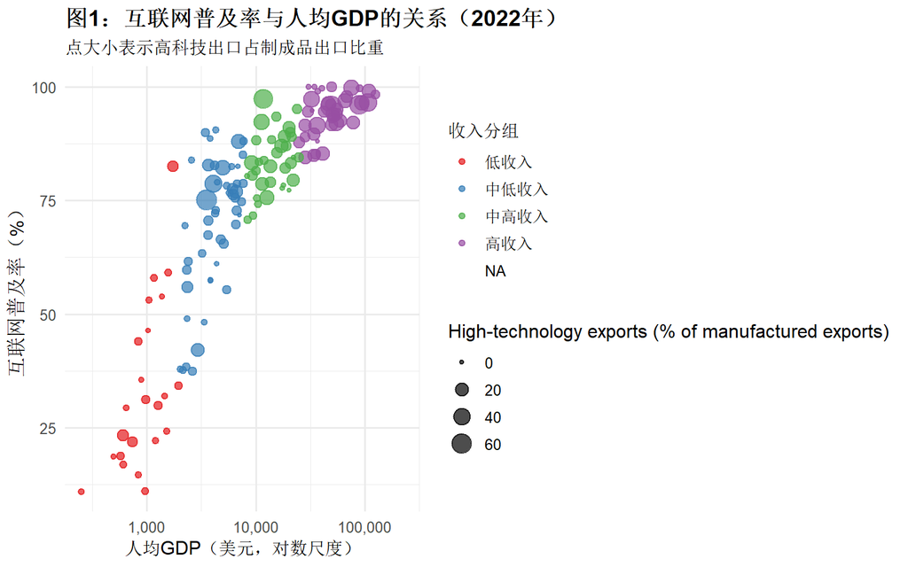

```r
ggplot(df %>% filter(year == 2022),
       aes(x = `GDP per capita (current US$)`,
           y = `Individuals using the Internet (% of population)`,
           color = income_group, size = `High-technology exports (% of manufactured exports)`)) +
  geom_point(alpha = 0.7) +
  scale_x_log10(labels = comma) +
  scale_color_brewer(palette = "Set1", name = "收入分组") +
  labs(title = "图1：互联网普及率与人均GDP的关系（2022年）",
       subtitle = "点大小表示高科技出口占制成品出口比重",
       x = "人均GDP（美元，对数尺度）",
       y = "互联网普及率（%）") +
  theme_minimal(base_size = 12) +
  theme(plot.title = element_text(face = "bold", size = 14))
```

**图1说明：** 互联网普及率与人均GDP呈明显的正相关关系。高收入国家的互联网普及率普遍超过80%，而低收入国家仍有较大差距。气泡大小反映高科技出口占比，高收入国家在科技产出方面同样占据优势。

### 4.2.2 图2：不同收入组数字化指数箱线图

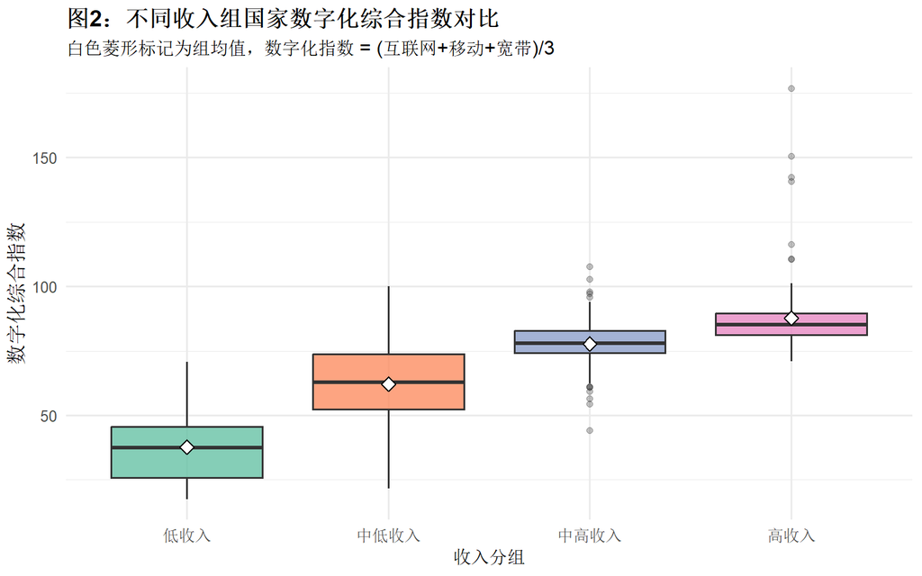

```r
ggplot(df %>% filter(!is.na(income_group), year >= 2020),
       aes(x = income_group, y = digital_index, fill = income_group)) +
  geom_boxplot(alpha = 0.8, outlier.alpha = 0.3) +
  stat_summary(fun = mean, geom = "point", shape = 23, size = 3, fill = "white") +
  scale_fill_brewer(palette = "Set2", guide = "none") +
  labs(title = "图2：不同收入组国家数字化综合指数对比",
       subtitle = "白色菱形标记为组均值，数字化指数 = (互联网+移动+宽带)/3",
       x = "收入分组", y = "数字化综合指数") +
  theme_minimal(base_size = 12) +
  theme(plot.title = element_text(face = "bold", size = 14))
```

### 4.2.3 图3：全球互联网普及率时间趋势折线图

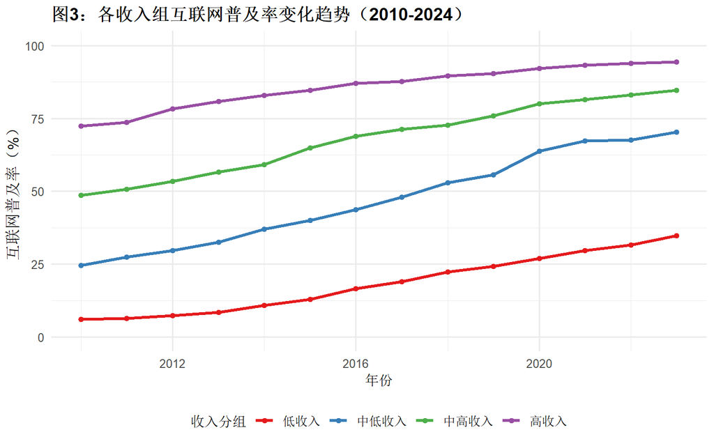

```r
df_trend <- df %>%
  filter(!is.na(income_group)) %>%
  group_by(year, income_group) %>%
  summarise(
    互联网普及率 = mean(`Individuals using the Internet (% of population)`, na.rm = TRUE),
    .groups = "drop"
  )

ggplot(df_trend, aes(x = year, y = 互联网普及率, color = income_group, group = income_group)) +
  geom_line(linewidth = 1.2) +
  geom_point(size = 1.5) +
  scale_color_brewer(palette = "Set1", name = "收入分组") +
  scale_y_continuous(limits = c(0, 100)) +
  labs(title = "图3：各收入组互联网普及率变化趋势（2010-2024）",
       x = "年份", y = "互联网普及率（%）") +
  theme_minimal(base_size = 12) +
  theme(plot.title = element_text(face = "bold", size = 14),
        legend.position = "bottom")
```

**图3说明：** 2010-2024年间，各收入组的互联网普及率均呈上升趋势。高收入国家已接近饱和（>90%），而中低收入和低收入国家增速更快，展现出”后发优势”。这一趋同现象表明全球数字鸿沟正在逐步缩小。